# Les réseaux de neurones

0. Introduction

1. Les neurones en pratique

2. Les avantages des réseaux de neurones : Pourquoi sont-ils intéressants ?

3. Les réseaux de neurones multicouches

4. Les enjeux

```python
from IPython.display import Image
```

## 0. Introduction

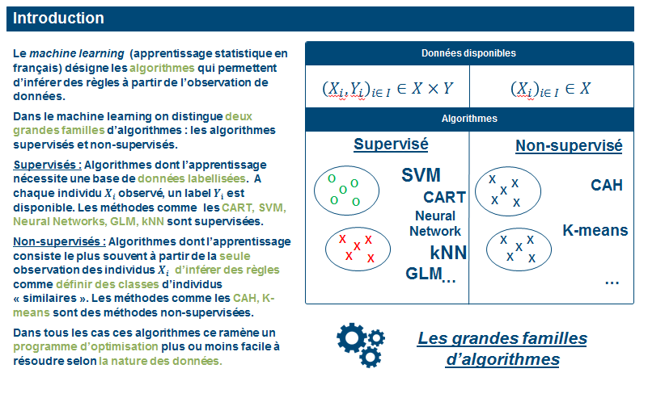

```python
Image('pics/overview.png')
```

#### Un peu d'histoire (merci Wikipédia).

Le premier neurone artificiel fonctionnel fut introduit par Franck Rosenblatt en 1957. Ce neurone qualifié de nos jours d'élementaire porte le nom de Perceptron, il a permis dans ses premières utilisations à determiner le sexe d'un individu présenté au travers d'une photo.

#### Schématiquement

on peut représenter un neurone élémentaire de cette façon :

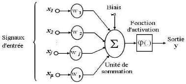

```python
Image('pics/Neurone_image.png')
```

#### Mathématiquement

un neurone formel élémentaire est défini par :

1. Un espace d'entrée $\mathcal{X}$ généralement $\mathbb{R}^n$ avec $n \in \mathbb{N}^*$
2. Un espace de sortie $\mathcal{Y}$ généralement $\mathbb{R}^p$ avec $p \in \mathbb{N}^*$ ou un ensemble dénombrable fini ( par exemple $\{-1,1\}$)
3. Un vecteur de paramètre $w \in \mathbb{R}^k$ où $k$ peut être différent de $n$ (par exemple lorsque l'on souhaite introduire un offset dans le cas d'un Kernel Trick)
4. Une fonction d'activation $\phi : \mathbb{R} \rightarrow \mathbb{R} $ . Cette fonction doit être monotone, dérivable et saturante afin de s'assurer de certaines propriétés de convergences d'après le théorème de Cybenko (au sens de l'analyse - ressemble avec les théorèmes de Stone-Weirstrass)

et on appelera neurone toute application $f_{w}$ de $\mathcal{X}$ dans $\mathcal{Y}$ définie par :

$$ f_{w}(x) = \phi (^t w x) ~~ \forall x\in \mathcal{X}$$

Si l'on revient au perceptron introduit par Rosenblatt, on assimile un neurone élémentaire à la fonction :

$$f_{w} : x\in \mathbb{R}^n \rightarrow y=sign(^t w x)$$

## 1. Les neurones en pratique

#### Dans notre "quotidien"

Beaucoup d'entre vous ont déjà utilisé des neurones élémentaires. En effet si l'on regarde d'un peu plus près tout modèle GLM peut s'interpréter comme un neurone formel où la fonction d'activation $\phi$ n'est d'autre que l'inverse de la fonction de lien canonique. Soit si l'on se base sur l'expression générale des GLM :

$$ g(E[Y|X])=^t w X $$

On retrouve en prenant $\phi = g^{-1} $ le même formalisme que celui introduit précédemment.

#### Petite démonstration du neurone élémenaire : le perceptron

```python
from Perceptron import *
```

```python
#génération d'un jeu de données fictif
trainset=createGaussianDataset(1,1,1,-1,-1,1,200)
perceptron=Perceptron(0.001,10)

#Entrainement des paramètres
perceptron.train(trainset)
```

```
train complete
```

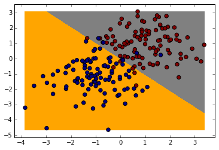

```python
%matplotlib inline

f=perceptron.predict
x=trainset.x
y=trainset.y

#visualisation
plot_frontiere(x,f)
plot2DSet(trainset)
```

Remarque : ce perceptron a été entrainé avec une méthode de descente de gradient stochastique et une fontion de coût de type HingeLoss. Je reviendrai sur ces termes par la suite.

#### Premières limites

Le perceptron ne peut traiter des cas non séparables. Il est facile de voir au travers l'illustration ci-dessus les limites des neurones purement linéaires. C'est une des raisons qui ont amené la communauté scientifique à ralentir les recherches sur les réseaux de neurones. Néanmoins, ce problème a été contourné dans les années 80-90 et le progrès technologique (à condition de bien le maitriser - c'est un enjeux d'actualité) permet aujourd'hui de traiter de nombreux problèmes.

## 2. Les avantages des réseaux de neurones : Pourquoi sont-ils intéressants ?

#### Pour bien comprendre

Dans un premier temps, comme il l'a été remarqué plus haut, les réseaux de neurones permettent de tenir compte d'une grande famille de fonction. Dans le domaine actuariel par exemple, ces derniers peuvent facilement être utilisés en tant que GLM. Mais en réalité, cela présente bien plus d'avantages. Par exemple, un réseaux de neurones peut-être utilisé dans certain cas en tant que modèle SVM pour des noyaux correctements choisis.

#### Le théorème de Cybenko

Soit $\phi$ une fonction réelle continue, non constante, croissante sur $\mathbb{R}$ et discriminante selon la mesure de Lebesgues (sans rentrer dans les détails théoriques on peut se limiter aux fonctions saturantes qui vérifient cette propriété). Soit $m \in \mathbb{N}*$, soit $f$ une fonction continue sur l'hypercube $I_m=[0,1]^m$ alors :

$\forall \epsilon >0 ~ \exists N\in \mathbb{N}^* ~|~ \forall n>N ,~ \exists (w_i)_{i \in [[ 1, n ]] } \in (\mathbb{R}^m)^n , \exists (\alpha_i,b_i)_{i \in [[ 1, n ]]} \in \mathbb{R}^n\times \mathbb{R}^n$ tels que :

$$ \forall x\in I_m, ~~ \left\{ \begin{array}{ll} F^n(x) = \sum \alpha_i \phi(w_i^T x + b_i) \\ |F^n(x)-f(x)|<\epsilon \end{array} \right. $$

#### En définitive, ce que cela implique

Ce théorème d'analyse permet de justifier la possibilité d'approcher toute fonction continue par un réseau de neurone. C'est la raison pour laquelle ce type de modèle est beaucoup utilisé afin d'approcher un critère de décision inconnu tout en élargissant l'ensemble des fonctions candidates.

Ainsi pour une tolérance d'erreur donnée, il existe alors un réseaux de neurone à une couche avec un nombre fini de neurones (potentiellement élevé) qui permet d'approcher n'importe quelle fonction de décision continue.

#### L'utilisation des réseaux aujourd'hui

- pour la classification : exemple d’espèces animales par espèce étant donnée une analyse ADN.
- reconnaissance de motif ; par exemple pour la Reconnaissance optique de caractères (OCR), et notamment par les banques pour vérifier le montant des chèques, par La Poste pour trier le courrier en fonction du code postal, etc. ; ou bien encore pour le déplacement automatisé de robots mobiles autonomes.
- approximation d’une fonction inconnue.
- modélisation accélérée d’une fonction connue mais très complexe à calculer avec exactitude ; par exemple certaines fonctions d’inversions utilisées pour décoder les signaux de télédétection émis par les satellites et les transformer en données sur la surface de la mer.

## 3. Les réseaux de neurones multicouches

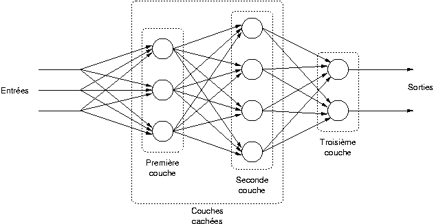

```python
Image('pics/multicouche_schema_vierge.png')
```

#### Présentation du modèle et des notations

Une fois que le modèle du neurone élémentaire fut maitrisé, dans les années 80-90 des chercheurs ont développé des architectures de neurones plus complexes permettant de traiter de problèmes non linéaires. Dans l'idée, celà consiste à relier chaque neurone à d'autres neurones. Les neurones sont organisés par couche et communiquent l'information entre eux. A des fins de simplicités et surtout parce que les autres structures ne présentent peu d'intérêts pour nous (trop exotiques et difficiles à calibrer), je présente ici que les structures dites linéaires dont voici un schéma.

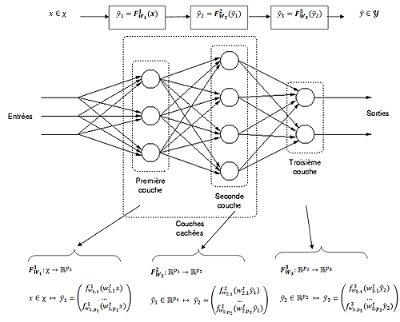

```python
Image('pics/multicouche_schema.png')
```

Pour faire le lien avec ce qui a déjà été présenté, ici, chaque petit cercle représente un neurone élémentaire. Chaque rectangle englobant plusieurs cercles représente une couche. On parle de couche d'entrée pour la première couche prenant en "input" les observation $x\in \mathcal{X}$, de couche de "sortie" pour la couche fournissant en "output" la prédiction $\hat{y} \in \mathcal{Y}$. Les autres couches sont courament appelées couches cachées.

#### Mathématiquement

De façon plus formelle et pour faire le lien avec la physique, chaque couche peut être associée à une fonction de transfert qui prend en entrée un vecteur et fournit en sortie un autre vecteur. Dans le cadre des réseaux de neurones, chaque fonction de transfert est une fonction paramètrique avec un nombre de paramètre proportionnel aux nombres de neurones de chaque couche. On rappelle au passage que nous disposons du théorème de Cybenko qui nous indique qu'une seule couche est censée être suffisante pour approcher n'importe quelle fonction continue.

**Notation pour chaque couche**

- $K \in \mathbb{N}^*$ : nombre de couches;
- $\forall k \in [[ 1 ,K ]] $ , $p_k$ représente le nombre de neurones dans la couche $k$;
- $\forall k \in [[ 1 ,K ]] $ ,$W_k$ désigne la matrice des paramètres associés à la couche $k$. Plus précisément, $W_k \in \mathcal{M}_{p_k,p_{k-1}}(\mathbb{R})$ et pour tout $l \in [[ 1 , p_k ]]$ , $w_{k,l} \in \mathbb{R}^{ p_{k-1}}$ désigne le vecteur de poids associé au neurone élémentaire $l$ de la couche $k$;
- On appellera $W = \{W_1,..,W_K\}$, l'ensemble des paramètres associés au réseau de neurones.
- $F^k_{W_k} : \mathbb{R}^{p_{k-1}} \rightarrow \mathbb{R}^{p_{k}}$ désigne la fonction de transfert associé à la couche $k$. Pour des raisons de simplification, on pourra également écrire $F^k$;
- $\hat{y}_k \in \mathbb{R}^{p_k}$ représentera le vecteur image de la couche $k \in [[ 1 , K ]]$;
- On appellera $F= F_W = F^1 \circ ... \circ F^K$ la fonction de transfert associée au réseau global. A ce titre, si $x\in \mathcal{X}$, on pourra noter $\hat y = F_W(x)$ .

Pour simplifier, prenons l'exemple du schéma ci-dessus et considérons un réseaux à trois couches. La première contient $p_1 = 3$ neurones, la seconde $p_2 = 4$ et la couche de sortie en contient $p_3 = 2$. Supposons par exemple que nous ayons en entrée des vecteurs $x\in \mathcal{X} = \mathbb{R}^5$.

Notre réseaux permet donc à partir de l'observation de 5 variables, de prédire un vecteur de taille 2. Pour entrainer notre réseau, supposons que nous disposons de $n \in \mathbb{N}^*$ observations $(x_i)_{i \in [[1, n]]} \in (\mathbb{R}^5)^n$ ainsi que de $n$ couples de labels $(y_i)_{i \in [[1, n]]} \in (\mathbb{R}^2)^n $

#### Qu'allons-nous calibrer ?

Il s'agit avant tout comme dans tout problème de modèlisation de bien déterminer nos paramètres et notre fonction objectif.

Si l'on se rappelle du schéma précédent, dans chaque couche existe un certain nombre de neurones élémentaires. Dans le cas de neurone linéaire (on verra plus tard qu'on peut toujours s'y ramener), chaque cercle représente une fonction de type :

$$ f : x \in \mathbb{R}^{p_{k-1}} \rightarrow \phi(^t w. x) \in \mathbb{R} $$

Par soucis de simplification, on prendra par la suite, la fonction d'activation $\phi$ égale à la fonction identité. Nous verrons comment prendre en compte la fonction d'activation plus loin.

Ainsi, pour la couche $k$ , on doit calibrer autant de vecteur $w$ que de neurones présents dans la couche, c'est-à-dire $p_k$. On peut ainsi paramètrer chaque couche par une matrice de paramètres $W_k \in \mathcal{M}_{p_{k-1},p_{k}}{(\mathbb{R})} $. On prendra comme convention que $p_{0} = 5$ c'est à dire la dimension de l'espace d'entrée $\mathcal{X}=\mathbb{R}^5$ .

Nous pouvons donc voir une couche de deux manières différentes. La première comme énoncé plus haut c'est à dire $p_k$ vecteurs $w$ à calibrer.

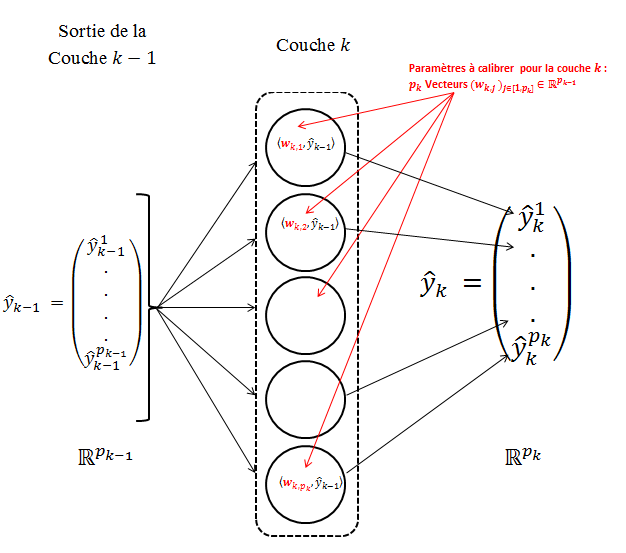

```python
Image('pics/Fonction de transfert.png')
```

La deuxième est matricielle : la sortie d'une couche s'obtient par produit matriciel d'une matrice de paramètres et d'un vecteur d'entrée égal à la sortie de la couche précédente si elle existe.

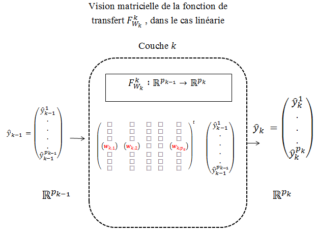

```python
Image('pics/Fonction de transfert_matrice.png')
```

Les paramètres à calibrer bien identifiés, on peut passer à l'apprentissage c'est-à-dire leur calibrage.

Une remarque : à ce stade on peut constater que le nombre de paramètres à calibrer peut vite être grand (relativement à la dimension du vecteur d'entrée) si l'on multiplie le nombre de couches et de neurones par couches.

#### Comment calibrer les différents paramètres ?

Comme tout problème de calibrage, il convient dans un premier temps de définir une fonction de coût $\Delta$ qu'il s'agira de miniser grâce aux paramètres. Si $W$ désigne l'ensemble des paramètres à calibrer (toute couche confondue), alors le problème de calibrage revient donc à déterminer $W^*$ de sorte que :

$$W^*= argmin [\sum_{i=1}^n \Delta (y_i, \hat{y_i}(W))] $$

Voici quelques exemples de fonctions de coût usuel :

- SquareLoss : $\Delta (y_i, \hat{y_i}(W))= ||y_i-\hat{y_i}||_2$
- HingeLoss : $\Delta (y_i, \hat{y_i}(W))= max (0, 1-y_i\hat{y_i})$

La liste est loin d'être exhaustive.

Le choix de cette fonction de coût est assez fondamentale pour le calibrage du modèle. Il est en effet possible de démontrer qu'elle joue un rôle dans l'approximation du meilleur classifieur. Certaines fonctions de coût, resteignent naturellement l'espace des fonctions candidates (exemple dans les régressions Ridge ou Lasso).

Point important : il n'y a aucune contrainte sur ce choix de cette fonction. Elle est laissé libre. Un domaine récent de la recherche en machine Learning consiste à faire de l'apprentissage de Métriques. C'est-à-dire à déterminer la meilleure mesure de coût. A creuser...

Une fois cette fonction de coût choisie, le calibrage du réseaux de neurones, comme beaucoup de modèle de machine learning, revient à résoudre un programme d'optimisation qui est :

$$\underset{W}{min} [ C(W) = \sum_{i=1}^n \Delta (y_i, \hat{y_i}(W))] $$

Ce programme est "facilement" résolvable si la fonction de coût $\Delta$ est convexe et dérivable ou du moins sous-différentiable. Cette propriété garantie en effet la convergence de nombreux algorithme vers un optimum global. Néanmoins cette hypothèse réstreint notre choix de la fonction de coût.

Dans la suite, on supposera donc que $\Delta$ est dérivable (différentiable) et convexe.

Sous ces hypothèses, pour résoudre le programme de minimisation il est alors suffisant d'annuler le gradient. Compte tenu du nombre de paramètres possiblement élevé et de la structure du réseau il n'est pas recommandé de résoudre ce programme par formule fermée. Pour annuler le gradient on utilise donc des algorithmes itératifs de descente de gradient. Pour avoir l'intuition de ces algorithmes, l'idée est d'effectuer un "déplacement" des paramètres qui permet de converger vers l'optimum global.

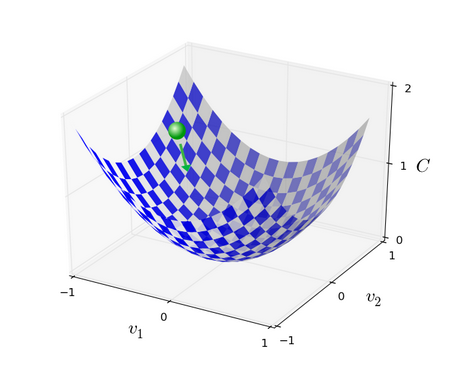

```python
Image('pics/descente_gradient.png')
```

En voici quelques-un présentés ci-dessous qui cherche à résoudre :

$$\underset{W}{min} [ C(W) = \sum_{i=1}^n \Delta (y_i, \hat{y_i}(W))] $$

A chaque itération $t$ de l'algorithme et ce jusqu'à ce qu'un certain critère d'arrêt (à déterminer par l'utilisateur) , pour chaque paramètre réel $w_{k,(i,j)}$ :

- L'algorithme de descente de gradient standard (ou batch)

  Effectue pour chaque observation $x_i$ avec $i \in [[1, n]]$ (on a donc dans cette algorithme autant d'itérations que d'observations)

  $$w^{t+1}_{k,(i,j)} \leftarrow w^{t}_{k,(i,j)} - \gamma_t\frac{ \partial{C} }{ \partial{w_{k,(i,j)} }} (w^{t}_{k,(i,j)})$$

  ```
    Cet algorithme nécessite à chaque itération de calculer autant de dérivés partielles que d'observations pour effectuer une descente moyenne. Dans le cas de données volumineuses (ex : >1 000 000 de lignes), cet algorithme n'est pas recommandé à moins d'être fortement parallélisé.
  ```

- L'algorithme de descente de gradient stochastique

  Dans cet algorithme, au lieu d'effectuer une descente moyenne à chaque itération, on commence par tirer une observation $x_i$ parmie les $n$ disponibles. On corrige ensuite les paramêtres du modèle de sorte à ce que la prédiction faite à partir de $x_i$ soit la plus proche possible de la vraie valeure $y_i$. On réitére ensuite la méthode jusqu'à avoir parcourue l'ensemble des données. La randomization du point de départ permet de casser toute "structure" initiale des données.

  On obtient ainsi pour cet algoritme :

  Pour $t:=1,...,n$ $$w^{t+1}_{k,(i,j)} \leftarrow w^{t}_{k,(i,j)} - \gamma_t\frac{ \partial{ \Delta } }{ \partial{ w_{k,(i,j)} }} (w^{t}_{k,(i,j)} , x_t , y_t) $$ $\forall k \in [[1,K]]$ (K :nombre de couches),

  $\forall (i,j)\in \mathbb{R}^{p_{k-1}}\times \mathbb{R}^{p_{k}}$

  ```
    L'avantage de cette méthode est qu'à chaque observation, il n'est pas nécessaire de calculer le gradient sur toutes les observations (plus de somme!). Cet algorithme s'appuie sur une convergence en probabilité vers un voisinage de l'optimum.
  ```

- L'algorithme de descente de gradient mini-batch

  Cet algorithme se situe un peu entre les deux premiers. Au lieu de considérer à chaque itération l'ensemble des observations (batch) ou à l'opposé, une seule observation (stochastique), à chaque itération on considére $b \in \mathbb{N}^*$ observations. $b$ est généralement fixé entre 2 et 100. Ainsi si par exemple $b =10$ et $n=1000$ l'algorithme se traduirait par :

  Pour $t:=1,11,21,31...,1000$ $$w^{t+1}_{k,(i,j)} \leftarrow w^{t}_{k,(i,j)} - \gamma_t \frac{1}{b} \sum_{l=1}^{b=10} \frac{ \partial{ \Delta } }{ \partial{ w_{k,(i,j)} }} (w^{t}_{k,(i,j)} , x_l , y_l) $$ $\forall k \in [[1,K]]$ (K :nombre de couches),

  $\forall (i,j)\in \mathbb{R}^{p_{k-1}}\times \mathbb{R}^{p_{k}}$

Attention: Les gradients ci-dessus dépendent des données d'observations $(x_i)$ et $(y_i)$ . Par soucis de simplication des notations, les dépendences n'ont pas toujours été explicitées dans les notations

$\gamma_t$ représente le pas de descente du gradient et peut varier selon l'itération $t$ . Il est fréquent de fixer $\gamma_t = \frac{1}{1+t}$

#### L'algorithme de descente de gradient appliqué aux réseaux de neurones multicouches

Reprenons notre exemple introduit précédemment :

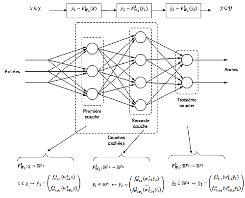

```python
Image('pics/multicouche_schema.png')
```

Appelons $F_W = F^3_{W_3}\circ F^2_{W_2}\circ F^1_{W_1}$ Plaçons nous dans le cas linéaire. C'est-à-dire que chaque cercle du schéma ci-dessus, représente un neurone linéaire autrement dit , une fonction du type : $f : x \rightarrow ^t w .x $

On prendra $p_1=3 $ , $p_2=4$ et $p_3=2$ pour pouvoir se référer au schéma. Les données $(x_i)$ seront supposées appartenir à $\mathbb{R}^{10}$.

Choisissons comme fonction de coût, la fonction de SquareLoss.

Le problème à optimiser devient donc :

$$\underset{W}{min} [ C(W) = \sum_{i=1}^n \Delta (y_i, \hat{y_i}(W)) = \sum_{i=1}^n ||y_i - \hat{y_i}(W)||_2 ] $$

Avec $W = \{ W_1, W_2,W_3 \} $ dont le cardinal est $10 \times 3 + 3\times 4 + 4\times 2 = 50 $ et $\hat{y_i}(W)= F_W(x_i) \in \mathbb{R}^2$. Il faut donc optimiser 50 paramètres selon l'une des méthodes présentées.

##### Calcul du gradient

Quelque soit la méthode de descente de gradient utilisée, il est nécessaire de pouvoir évaluer :

$$\frac{ \partial{ \Delta } }{ \partial{ w_{k,(i,j)} }} (w^{t}_{k,(i,j)} , x_t , y_t) $$

$\forall k \in [[1,K]]$ (K :nombre de couches),

$\forall (i,j)\in \mathbb{R}^{p_{k-1}}\times \mathbb{R}^{p_{k}}$

Qualitativement, ce terme représente la sensibilité de la fonction de coût au paramètre $w_{k,(i,j)}$. Cette notion est importante pour bien comprendre la suite et surtout pouvoir visualiser comment implémenter un réseau de neurones multicouche.

Dans notre exemple, la couche de sortie est de dimension 2 ce qui donne :

$$\Delta (y_t, \hat{y_t}(W)) = ||y_t - \hat{y_t}(W)||_2 =(y_i^1 - F_W^{(1)}(x_t))^2 + (y_i^2 - F_W^{(2)}(x_t))^2$$

On en déduit :

$$ \frac{ \partial{ \Delta } }{ \partial{ w_{k,(i,j)} }} (w^{t}_{k,(i,j)} , x_t , y_t) = - 2 \frac{ \partial{ F_W^{(1)} } }{ \partial{ w_{k,(i,j)} }}(x_t) (y_t^1 - F_W^{(1)}(x_t)) - 2 \frac{ \partial{ F_W^{(2)} } }{ \partial{ w_{k,(i,j)} }}(x_t) (y_t^2 - F_W^{(2)}(x_t)) $$

On ne détaillera par la suite que les calculs pour une seule des composantes de la couche de sortie.

Supposons désormais que par exemple $k=2$, par théorème de dérivation des fonctions composées en utilisant le fait que $F_W = F^3_{W_3}\circ F^2_{W_2}\circ F^1_{W_1}$ et en s'intéressant qu'à la première composante de $F$ (on rappel que dans notre exemple $F_W : \mathbb{R}^{10} \rightarrow \mathbb{R}^{2}$ et donc que pour $x \in \mathbb{R}^{10} $ , $F_W(x)= (F^{(1)}_W(x),F^{(2)}_W(x))$.

$$\frac{ \partial{ F_W^{(1)} } }{ \partial{ w_{k=2,(i,j)} }}(x_t) = \sum_{q=1}^{p_2=4} \frac{ \partial_1{F^3_{W_3}} }{\partial{e_q}}( F^2_{W_2}\circ F^1_{W_1}(x_t)) \times \frac{ \partial_q{ F^2_{W_2}\circ F^1_{W_1} }} { \partial{ w_{2,(i,j)} } }(x_t) $$

Si l'on analyse cette forme d'un peu plus près, on remarque que :

- le premier terme de la somme représente finalement la dérivée du premier neurone de la troisième couche en fonction de ses coordonnées prises en entrées. C'est un terme où les différents paramètres $w_{2,(i,j)}$ représentent des constantes vis-à-vis de la dérivée.
- le second terme représente la dérivée de la sortie de la deuxième couche par rapport au paramètre $w_{2,(i,j)}$. Cette dernière est facilement calculable dans le cas linéaire puisque seul le $j ^{ième}$ neurone de la couche 2 dépend de ce paramètre.

La formule a été appliqué pour le cas particulier où $k=2$. Pour $k=1$ cela aurait donné :

$$\frac{ \partial{ F_W^{(1)} } }{ \partial{ w_{k=1,(i,j)} }}(x_t) = \sum_{q=1}^{p_1=3} \frac{ \partial_1{F^3_{W_3}\circ F^2_{W_2} } }{\partial{e_q}}( F^1_{W_1}(x_t)) \times \frac{ \partial_q{F^1_{W_1} }} { \partial{ w_{1,(i,j)} } }(x_t) $$

En réitérant le théroème de dérivation des fonctions composées, on remarque de plus que :

$$\forall q \in [[1,3]], \frac{ \partial_1{F^3_{W_3}\circ F^2_{W_2} } }{\partial{e_q}}(z) = \sum_{l=1}^{p_2=4}\frac{ \partial_1{F^3_{W_3}}}{\partial{e_l}}( F^2_{W_2}(z)) \times \frac{ \partial_l{F^2_{W_2}}}{\partial{e_q}}(z)$$

#### L'intérêt d'expliciter tous ces calculs : la Backpropagation

Les précédentes décompositions jouent un rôle fondamentale dans l'implémentation des réseaux de neurones. En effet, si l'on regarde ces expressions, chaque dérivée partielle par rapport à un paramètre peut s'exprimer en fonction :

- d'une dérivée partielle qui dépend d'une couche qui contient le paramètre.
- et d'une autre dépendant uniquement de la couche suivante (soit indépendant du paramètre) !

  On devine ici un moyen récursif de calculer le gradient (appelé backpropagation) sans devoir, à chaque fois que l'on rajoute une couche, calculer explicitement la fonction de transfert globale et ses multiples dérivées partielles. Pour les cas où il y a une ou deux couches le calcul peut-être abouti assez simplement, mais à partir de 3 couches, les calculs deviennent vite fastidieux et rendraient l'implémentation peu opérationnelle...

  Pour pouvoir introduire le principe de backpropagation commençons par illustrer le principe de propagation. Supposons qu'une erreur soit commise dans l'estimation d'un paramètre associé à un neurone. Ce neurone étant relié à la couche de sortie aux travers de différentes couches, l'erreur est alors propagée dans chacun des neurones suivant le neurone erroné.

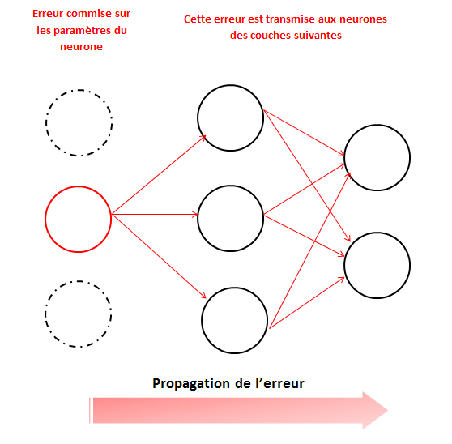

```python
Image('pics/propagation_erreur.png')
```

Néanmoins, ce qui est facilement observable dans notre modèle neuronal c'est la sortie $\hat{y}$ fournie par le réseau de neurone pour une entrée $x$ donnée. Connaissant l'erreur commise sur la prédiction, c'est-à-dire $\delta =\hat{y} -y $, on aimerait corriger cette erreur en la rétroprogeant dans le réseau pour ainsi corriger les paramètres à l'origine de cette erreur. Cela revient à remonter à "contre courant" le schéma de la propagation précédent. L'idée est donc d'utiliser l'erreur ou autrement dit, la sensibilité de la couche de sortie pour pouvoir estimé l'erreur de l'avant dernière couche et ainsi de suite. On préfére ainsi parler de rétropropagation ou backpropagation dans le cadre des réseaux de neurones.

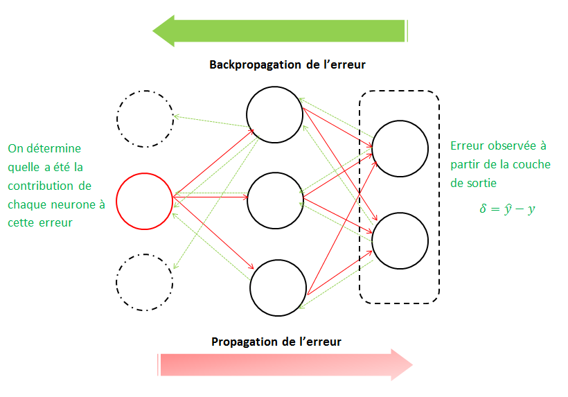

```python
Image('pics/backpropagation.png')
```

Qu'elle est le lien avec les calculs de gradient présentés précédement ?

Une interprétation de la dérivée d'une fonction par rapport à ses coordonnées peut être énoncée comme telle : "Si je modifie légérement l'entrée de ma fonction, comment va réagir la sortie. Ou autrement dit, quelle erreur cela va entrainer ".

Sur la base de cette idée, rappelons l'exemple précédent où l'on s'intéressé à l'erreur commise par un paramètre de la couche 2 soit :

$$\frac{ \partial{ F_W^{(1)} } }{ \partial{ w_{k=2,(i,j)} }}(x_t) = \sum_{q=1}^{p_2=4} \frac{ \partial_1{F^3_{W_3}} }{\partial{e_q}}( F^2_{W_2}\circ F^1_{W_1}(x_t)) \times \frac{ \partial_q{ F^2_{W_2}\circ F^1_{W_1} }} { \partial{ w_{2,(i,j)} } }(x_t) $$

le terme $\frac{ \partial_1{F^3_{W_3}} }{\partial{e_q}}$ n'est autre que l'erreur commise par la couche 3 ! Pour anticiper sur la suite, on parlera de façon peu formelle de " $\delta$ de module suivant" ou encore "d'erreur engendrée par le module suivant".

#### Retour sur notre exemple linéaire

A ce stade, on remarquera que nous avons conservé les expressions les plus générales possibles. Nous n'avons pas encore utilisé l'hypothèse faite sur la linéarité des différents neurones. Appliquons désormais les différentes formules explicitées précédemment au cas linéaire c'est-à-dire où chaque neurone est de la forme $f : x \rightarrow ^t w .x $ sans aucune fonction d'activation.

Cet exemple nous servira par la suite de référence pour illustrer la partie d'implémentation du réseau de neurone.

Ainsi,

$$\frac{ \partial{ F_W^{(1)} } }{ \partial{ w_{k=2,(i,j)} }}(x_t) = \sum_{q=1}^{p_2=4} \frac{ \partial_1{F^3_{W_3}} }{\partial{e_q}}( F^2_{W_2}\circ F^1_{W_1}(x_t)) \times \frac{ \partial_q{ F^2_{W_2}\circ F^1_{W_1} }} { \partial{ w_{2,(i,j)} } }(x_t) $$

où

$$\frac{ \partial_q{ F^2_{W_2}\circ F^1_{W_1} }} { \partial{ w_{2,(i,j)} }} = F^1_{W_1}(x)[i] ~ si ~q=j ~et~0~sinon$$

En effet seul le $j^{ième}$ neurone de la deuxième couche dépend du paramètre $w_{2,(i,j)}$. Ce terme n'est d'autre que la $i^{ème}$ composante du vecteur d'entrée de la couche 2.

Finalement l'expression se simplifie en :

$$\frac{ \partial{ F_W^{(1)} } }{ \partial{ w_{k=2,(i,j)} }}(x_t) = \frac{ \partial_1{F^3_{W_3}} }{\partial{e_j}}( F^2_{W_2}\circ F^1_{W_1}(x_t)) \times F^1_{W_1}(x_t)[i] $$

avec $j \in [[1 , p_2=4]]$ et $i\in [[1, p_1=3]]$.

D'autre part, $\frac{ \partial_1{F^3_{W_3}} }{\partial{e_j}}$ s'exprime également facilement dans le cas linéaire :

$$\frac{\partial_1{F^3_{W_3}} }{\partial{e_j}} = w_{3,(j,1)}$$

On rappelle le schéma suivant pour mieux visiualiser le calcul.

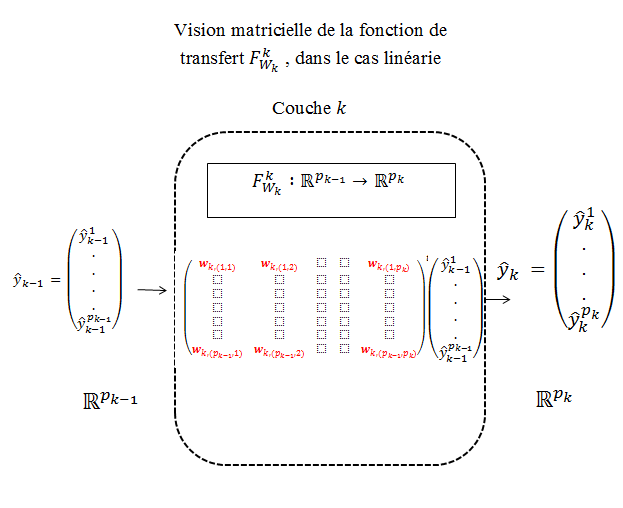

```python
Image('pics/Fonction de transfert_explicite.png')
```

Finalement dans le cas d'un réseau linéaire, notre expression devient :

$$\frac{ \partial{ F_W^{(1)} } }{ \partial{ w_{k=2,(i,j)} }}(x_t) = w_{3,(j,1)} \times F^1_{W_1}(x_t)[i] $$

avec $j \in [[1 , p_2=4]]$ et $i\in [[1, p_1=3]]$.

## 4. Les enjeux

Si la recherche continue et émerge sur le réseaux de neurones c'est qu'il existe encore certaines diffcultés dans le calibrage voir même l'interpréation.

#### Le problème du Deep Learning

Lorsque que le nombre de couche devient trop important, le phénomène de backpropagation entraine la faible modification des paramètres des couches les plus primaires. En effet, depuis la couche finale jusqu'aux couches initiales, l'erreur est en quelque sort diluée au fur et à mesure que l'on remonte le réseau de neurone. Ceci a pour conséquence qu'au bout d'un nombre d'itérations important, les paramètres des couches primaires restent toujours proches des valeurs initiales.

Ceci pose problème dans la mesure ou les première couches permettent en générale de capter l'information par réduction de dimension.

#### L'auto-encodage

Face à ce problème certain chercheur mette en avant l'avantage de l'auto-encodage pour pouvoir initialiser les paramètres en des valeurs "optimales". Ce terme reste entre guillemet car je n'ai pas trouvé de démonstration théorique. Les résultats sont surtout d'ordre expérimental. On retiendra cette méthode pour l'initialisation de nos paramètres si cela devenait nécessaire.

#### Les réseaux de neurones, une boite noire ?

- Comment expliquer le lien entre l'entrée et la sortie ?
- Comment interpréter les paramètres ?
- Peut-on analyser le rôle d'un neurone au sein du réseau ?

Ce sont autant de questions auxquelles des chercheurs tentent de répondre. C'est en général du cas par cas... C'est une autre piste de recherhce pour mes travaux.

#### L'optimisation de l'apprentissage

Les réseaux de neurones pourraient être exploités avec un grand volume de données . Seulement l'optimisation et les calculs des gradients peuvent entrainer un temps de calibrage très long. Il existe des méthodes permettant la parallélisation de ces calculs. Une piste de recherche et d'amélioration est donc envisagé dans ce sens. Utilisation de GPU , Multiproccessing grâce au serveur .

## Sources

- Approximation by superpositions of a sigmoidal function - G. Cybenko ,Mathematics of Control, Signals and Systems 1989, Volume 2, Issue 4, pp 303-314
- N. Le Roux, M. Schmidt, and F. Bach. A stochastic gradient method with an exponential convergence rate for strongly-convex optimization with finite training sets. Technical Report 00674995, HAL, 2012.
- N. Le Roux, M. Schmidt, and F. Bach. A stochastic gradient method with an exponential convergence rate for strongly-convex optimization with finite training sets. Technical Report 00674995, HAL, 2013.
- X.Gourdon , Maths en tete Mathematiques, Analyse , Ellipses, 1998
- Notes de cours, P.Galliginari , L. Denoyer , UMPC Paris VI Lip6 - Jussieu Master DAC 2014-2015
- Huajin Tang, Kay Chen Tan, Zhang Yi ,Neural Networks- Computational Models and Applications (Studies in Computational Intelligence, Volume 53) 2007